# Risk Factor Analysis

## Outcome Variable

**Outcome Variable:** pers_wast

## Predictor Variables

**Intervention Variable:** hhwealth_quart

**Adjustment Set:**

unadjusted

## Stratifying Variables

The analysis was stratified on these variable(s):

- agecat
- studyid
- country

## Data Summary

| agecat | studyid | country | hhwealth_quart | pers_wast | n_cell | n | outcome_variable |
| --- | --- | --- | --- | --- | --- | --- | --- |
| 0-24 months | ki0047075b-MAL-ED | BANGLADESH | Wealth Q4 | 0 | 57 | 242 | pers_wast |
| 0-24 months | ki0047075b-MAL-ED | BANGLADESH | Wealth Q4 | 1 | 4 | 242 | pers_wast |
| 0-24 months | ki0047075b-MAL-ED | BANGLADESH | Wealth Q1 | 0 | 57 | 242 | pers_wast |
| 0-24 months | ki0047075b-MAL-ED | BANGLADESH | Wealth Q1 | 1 | 3 | 242 | pers_wast |
| 0-24 months | ki0047075b-MAL-ED | BANGLADESH | Wealth Q2 | 0 | 56 | 242 | pers_wast |
| 0-24 months | ki0047075b-MAL-ED | BANGLADESH | Wealth Q2 | 1 | 5 | 242 | pers_wast |
| 0-24 months | ki0047075b-MAL-ED | BANGLADESH | Wealth Q3 | 0 | 59 | 242 | pers_wast |
| 0-24 months | ki0047075b-MAL-ED | BANGLADESH | Wealth Q3 | 1 | 1 | 242 | pers_wast |
| 0-24 months | ki0047075b-MAL-ED | BRAZIL | Wealth Q4 | 0 | 52 | 210 | pers_wast |
| 0-24 months | ki0047075b-MAL-ED | BRAZIL | Wealth Q4 | 1 | 1 | 210 | pers_wast |
| 0-24 months | ki0047075b-MAL-ED | BRAZIL | Wealth Q1 | 0 | 52 | 210 | pers_wast |
| 0-24 months | ki0047075b-MAL-ED | BRAZIL | Wealth Q1 | 1 | 1 | 210 | pers_wast |
| 0-24 months | ki0047075b-MAL-ED | BRAZIL | Wealth Q2 | 0 | 53 | 210 | pers_wast |
| 0-24 months | ki0047075b-MAL-ED | BRAZIL | Wealth Q2 | 1 | 0 | 210 | pers_wast |
| 0-24 months | ki0047075b-MAL-ED | BRAZIL | Wealth Q3 | 0 | 51 | 210 | pers_wast |
| 0-24 months | ki0047075b-MAL-ED | BRAZIL | Wealth Q3 | 1 | 0 | 210 | pers_wast |
| 0-24 months | ki0047075b-MAL-ED | INDIA | Wealth Q4 | 0 | 55 | 235 | pers_wast |
| 0-24 months | ki0047075b-MAL-ED | INDIA | Wealth Q4 | 1 | 4 | 235 | pers_wast |
| 0-24 months | ki0047075b-MAL-ED | INDIA | Wealth Q1 | 0 | 55 | 235 | pers_wast |
| 0-24 months | ki0047075b-MAL-ED | INDIA | Wealth Q1 | 1 | 5 | 235 | pers_wast |
| 0-24 months | ki0047075b-MAL-ED | INDIA | Wealth Q2 | 0 | 52 | 235 | pers_wast |
| 0-24 months | ki0047075b-MAL-ED | INDIA | Wealth Q2 | 1 | 6 | 235 | pers_wast |
| 0-24 months | ki0047075b-MAL-ED | INDIA | Wealth Q3 | 0 | 53 | 235 | pers_wast |
| 0-24 months | ki0047075b-MAL-ED | INDIA | Wealth Q3 | 1 | 5 | 235 | pers_wast |
| 0-24 months | ki0047075b-MAL-ED | NEPAL | Wealth Q4 | 0 | 58 | 236 | pers_wast |
| 0-24 months | ki0047075b-MAL-ED | NEPAL | Wealth Q4 | 1 | 1 | 236 | pers_wast |
| 0-24 months | ki0047075b-MAL-ED | NEPAL | Wealth Q1 | 0 | 58 | 236 | pers_wast |
| 0-24 months | ki0047075b-MAL-ED | NEPAL | Wealth Q1 | 1 | 1 | 236 | pers_wast |
| 0-24 months | ki0047075b-MAL-ED | NEPAL | Wealth Q2 | 0 | 59 | 236 | pers_wast |
| 0-24 months | ki0047075b-MAL-ED | NEPAL | Wealth Q2 | 1 | 0 | 236 | pers_wast |

[output cut: 378 more lines]

The following strata were considered:

- agecat: 0-24 months, studyid: ki0047075b-MAL-ED, country: BANGLADESH
- agecat: 0-24 months, studyid: ki0047075b-MAL-ED, country: BRAZIL
- agecat: 0-24 months, studyid: ki0047075b-MAL-ED, country: INDIA
- agecat: 0-24 months, studyid: ki0047075b-MAL-ED, country: NEPAL
- agecat: 0-24 months, studyid: ki0047075b-MAL-ED, country: PERU
- agecat: 0-24 months, studyid: ki0047075b-MAL-ED, country: SOUTH AFRICA
- agecat: 0-24 months, studyid: ki0047075b-MAL-ED, country: TANZANIA, UNITED REPUBLIC OF
- agecat: 0-24 months, studyid: ki1000108-CMC-V-BCS-2002, country: INDIA
- agecat: 0-24 months, studyid: ki1000108-IRC, country: INDIA
- agecat: 0-24 months, studyid: ki1017093b-PROVIDE, country: BANGLADESH
- agecat: 0-24 months, studyid: ki1066203-TanzaniaChild2, country: TANZANIA, UNITED REPUBLIC OF
- agecat: 0-24 months, studyid: ki1113344-GMS-Nepal, country: NEPAL
- agecat: 0-24 months, studyid: ki1114097-CONTENT, country: PERU
- agecat: 0-24 months, studyid: ki1135781-COHORTS, country: GUATEMALA
- agecat: 0-24 months, studyid: ki1135781-COHORTS, country: PHILIPPINES
- agecat: 0-24 months, studyid: ki1148112-LCNI-5, country: MALAWI
- agecat: 0-24 months, studyid: kiGH5241-JiVitA-3, country: BANGLADESH
- agecat: 0-24 months, studyid: kiGH5241-JiVitA-4, country: BANGLADESH
- agecat: 0-6 months, studyid: ki0047075b-MAL-ED, country: BANGLADESH
- agecat: 0-6 months, studyid: ki0047075b-MAL-ED, country: BRAZIL
- agecat: 0-6 months, studyid: ki0047075b-MAL-ED, country: INDIA
- agecat: 0-6 months, studyid: ki0047075b-MAL-ED, country: NEPAL
- agecat: 0-6 months, studyid: ki0047075b-MAL-ED, country: PERU
- agecat: 0-6 months, studyid: ki0047075b-MAL-ED, country: SOUTH AFRICA
- agecat: 0-6 months, studyid: ki0047075b-MAL-ED, country: TANZANIA, UNITED REPUBLIC OF
- agecat: 0-6 months, studyid: ki1000108-CMC-V-BCS-2002, country: INDIA
- agecat: 0-6 months, studyid: ki1000108-IRC, country: INDIA
- agecat: 0-6 months, studyid: ki1017093b-PROVIDE, country: BANGLADESH
- agecat: 0-6 months, studyid: ki1066203-TanzaniaChild2, country: TANZANIA, UNITED REPUBLIC OF
- agecat: 0-6 months, studyid: ki1113344-GMS-Nepal, country: NEPAL
- agecat: 0-6 months, studyid: ki1114097-CONTENT, country: PERU
- agecat: 0-6 months, studyid: ki1135781-COHORTS, country: PHILIPPINES
- agecat: 0-6 months, studyid: kiGH5241-JiVitA-3, country: BANGLADESH
- agecat: 6-24 months, studyid: ki0047075b-MAL-ED, country: BANGLADESH
- agecat: 6-24 months, studyid: ki0047075b-MAL-ED, country: BRAZIL
- agecat: 6-24 months, studyid: ki0047075b-MAL-ED, country: INDIA
- agecat: 6-24 months, studyid: ki0047075b-MAL-ED, country: NEPAL
- agecat: 6-24 months, studyid: ki0047075b-MAL-ED, country: PERU
- agecat: 6-24 months, studyid: ki0047075b-MAL-ED, country: SOUTH AFRICA
- agecat: 6-24 months, studyid: ki0047075b-MAL-ED, country: TANZANIA, UNITED REPUBLIC OF
- agecat: 6-24 months, studyid: ki1000108-CMC-V-BCS-2002, country: INDIA
- agecat: 6-24 months, studyid: ki1000108-IRC, country: INDIA
- agecat: 6-24 months, studyid: ki1017093b-PROVIDE, country: BANGLADESH
- agecat: 6-24 months, studyid: ki1066203-TanzaniaChild2, country: TANZANIA, UNITED REPUBLIC OF
- agecat: 6-24 months, studyid: ki1113344-GMS-Nepal, country: NEPAL
- agecat: 6-24 months, studyid: ki1114097-CONTENT, country: PERU
- agecat: 6-24 months, studyid: ki1135781-COHORTS, country: GUATEMALA
- agecat: 6-24 months, studyid: ki1135781-COHORTS, country: PHILIPPINES
- agecat: 6-24 months, studyid: ki1148112-LCNI-5, country: MALAWI
- agecat: 6-24 months, studyid: kiGH5241-JiVitA-3, country: BANGLADESH
- agecat: 6-24 months, studyid: kiGH5241-JiVitA-4, country: BANGLADESH

### Dropped Strata

Some strata were dropped due to rare outcomes:

- agecat: 0-24 months, studyid: ki0047075b-MAL-ED, country: BANGLADESH
- agecat: 0-24 months, studyid: ki0047075b-MAL-ED, country: BRAZIL
- agecat: 0-24 months, studyid: ki0047075b-MAL-ED, country: INDIA
- agecat: 0-24 months, studyid: ki0047075b-MAL-ED, country: NEPAL
- agecat: 0-24 months, studyid: ki0047075b-MAL-ED, country: PERU
- agecat: 0-24 months, studyid: ki0047075b-MAL-ED, country: SOUTH AFRICA
- agecat: 0-24 months, studyid: ki0047075b-MAL-ED, country: TANZANIA, UNITED REPUBLIC OF
- agecat: 0-24 months, studyid: ki1000108-CMC-V-BCS-2002, country: INDIA
- agecat: 0-24 months, studyid: ki1017093b-PROVIDE, country: BANGLADESH
- agecat: 0-24 months, studyid: ki1114097-CONTENT, country: PERU
- agecat: 0-24 months, studyid: ki1135781-COHORTS, country: GUATEMALA
- agecat: 0-24 months, studyid: ki1148112-LCNI-5, country: MALAWI
- agecat: 0-6 months, studyid: ki0047075b-MAL-ED, country: BANGLADESH
- agecat: 0-6 months, studyid: ki0047075b-MAL-ED, country: BRAZIL
- agecat: 0-6 months, studyid: ki0047075b-MAL-ED, country: INDIA
- agecat: 0-6 months, studyid: ki0047075b-MAL-ED, country: NEPAL
- agecat: 0-6 months, studyid: ki0047075b-MAL-ED, country: PERU
- agecat: 0-6 months, studyid: ki0047075b-MAL-ED, country: SOUTH AFRICA
- agecat: 0-6 months, studyid: ki0047075b-MAL-ED, country: TANZANIA, UNITED REPUBLIC OF
- agecat: 0-6 months, studyid: ki1017093b-PROVIDE, country: BANGLADESH
- agecat: 0-6 months, studyid: ki1114097-CONTENT, country: PERU
- agecat: 0-6 months, studyid: kiGH5241-JiVitA-3, country: BANGLADESH
- agecat: 6-24 months, studyid: ki0047075b-MAL-ED, country: BANGLADESH
- agecat: 6-24 months, studyid: ki0047075b-MAL-ED, country: BRAZIL
- agecat: 6-24 months, studyid: ki0047075b-MAL-ED, country: INDIA
- agecat: 6-24 months, studyid: ki0047075b-MAL-ED, country: NEPAL
- agecat: 6-24 months, studyid: ki0047075b-MAL-ED, country: PERU
- agecat: 6-24 months, studyid: ki0047075b-MAL-ED, country: SOUTH AFRICA
- agecat: 6-24 months, studyid: ki0047075b-MAL-ED, country: TANZANIA, UNITED REPUBLIC OF
- agecat: 6-24 months, studyid: ki1000108-CMC-V-BCS-2002, country: INDIA
- agecat: 6-24 months, studyid: ki1017093b-PROVIDE, country: BANGLADESH
- agecat: 6-24 months, studyid: ki1114097-CONTENT, country: PERU
- agecat: 6-24 months, studyid: ki1135781-COHORTS, country: GUATEMALA
- agecat: 6-24 months, studyid: ki1148112-LCNI-5, country: MALAWI

## Methods Detail

We’re interested in the causal parameters $E[Y_a]$ for all values of $a \in \mathcal{A}$. These parameters represent the mean outcome if, possibly contrary to fact, we intervened to set all units to have $A=a$. Under the randomization and positivity assumptions, these are identified by the statistical parameters $\psi_a=E_W[E_{Y|A,W}(Y|A=a,W)]$. In addition, we’re interested in the mean of $Y$, $E[Y]$ under no intervention (the observed mean). We will estimate these parameters by using SuperLearner to fit the relevant likelihood factors – $E_{Y|A,W}(Y|A=a,W)$ and $p(A=a|W)$, and then updating our likelihood fit using a joint TMLE.

For unadjusted analyses ($W=\{\}$), initial likelihoods were estimated using Lrnr_glm to estimate the simple $E(Y|A)$ and Lrnr_mean to estimate $p(A)$. For adjusted analyses, a small library containing Lrnr_glmnet, Lrnr_xgboost, and Lrnr_mean was used.

Having estimated these parameters, we will then use the delta method to estimate relative risks and attributable risks relative to a prespecified baseline level of $A$.

# Results Detail

## Results Plots

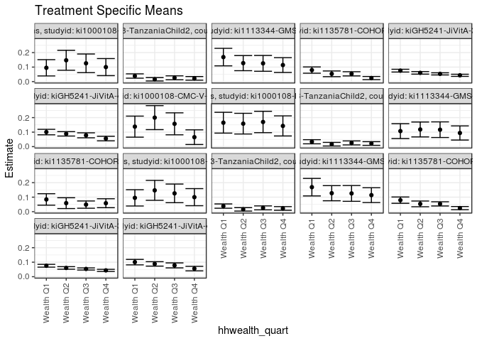

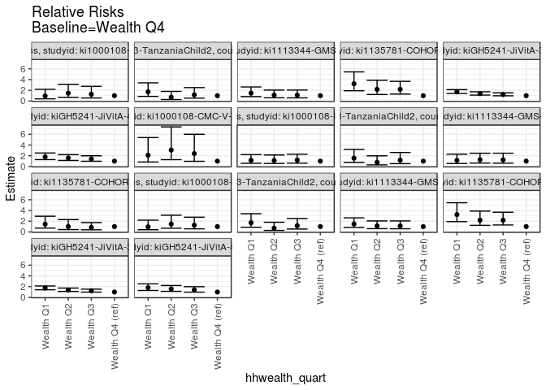

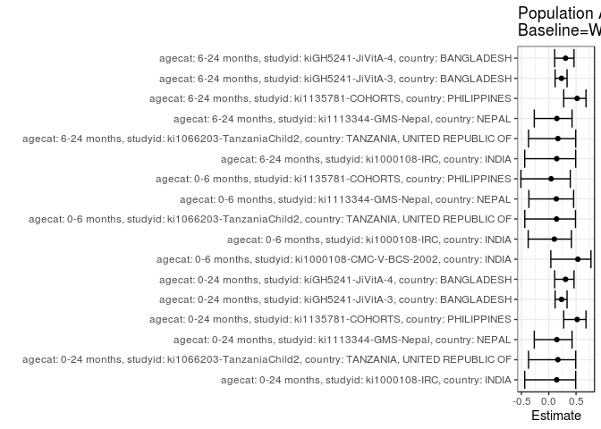

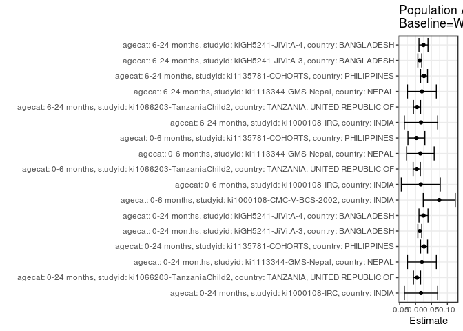

## Results Table

### Parameter: TSM

| agecat | studyid | country | intervention_level | baseline_level | estimate | ci_lower | ci_upper |
| --- | --- | --- | --- | --- | --- | --- | --- |
| 0-24 months | ki1000108-IRC | INDIA | Wealth Q4 | NA | 0.1000000 | 0.0411292 | 0.1588708 |
| 0-24 months | ki1000108-IRC | INDIA | Wealth Q1 | NA | 0.0952381 | 0.0390226 | 0.1514536 |
| 0-24 months | ki1000108-IRC | INDIA | Wealth Q2 | NA | 0.1470588 | 0.0782438 | 0.2158739 |
| 0-24 months | ki1000108-IRC | INDIA | Wealth Q3 | NA | 0.1262136 | 0.0620017 | 0.1904255 |
| 0-24 months | ki1066203-TanzaniaChild2 | TANZANIA, UNITED REPUBLIC OF | Wealth Q4 | NA | 0.0223881 | 0.0098607 | 0.0349154 |
| 0-24 months | ki1066203-TanzaniaChild2 | TANZANIA, UNITED REPUBLIC OF | Wealth Q1 | NA | 0.0385208 | 0.0237112 | 0.0533304 |
| 0-24 months | ki1066203-TanzaniaChild2 | TANZANIA, UNITED REPUBLIC OF | Wealth Q2 | NA | 0.0160183 | 0.0042447 | 0.0277919 |
| 0-24 months | ki1066203-TanzaniaChild2 | TANZANIA, UNITED REPUBLIC OF | Wealth Q3 | NA | 0.0261682 | 0.0126381 | 0.0396983 |
| 0-24 months | ki1113344-GMS-Nepal | NEPAL | Wealth Q4 | NA | 0.1140940 | 0.0630030 | 0.1651849 |
| 0-24 months | ki1113344-GMS-Nepal | NEPAL | Wealth Q1 | NA | 0.1689189 | 0.1085043 | 0.2293335 |
| 0-24 months | ki1113344-GMS-Nepal | NEPAL | Wealth Q2 | NA | 0.1273885 | 0.0751925 | 0.1795846 |
| 0-24 months | ki1113344-GMS-Nepal | NEPAL | Wealth Q3 | NA | 0.1258741 | 0.0714615 | 0.1802867 |
| 0-24 months | ki1135781-COHORTS | PHILIPPINES | Wealth Q4 | NA | 0.0245796 | 0.0136622 | 0.0354969 |
| 0-24 months | ki1135781-COHORTS | PHILIPPINES | Wealth Q1 | NA | 0.0794702 | 0.0578963 | 0.1010441 |
| 0-24 months | ki1135781-COHORTS | PHILIPPINES | Wealth Q2 | NA | 0.0536779 | 0.0339783 | 0.0733776 |
| 0-24 months | ki1135781-COHORTS | PHILIPPINES | Wealth Q3 | NA | 0.0537057 | 0.0392222 | 0.0681892 |
| 0-24 months | kiGH5241-JiVitA-3 | BANGLADESH | Wealth Q4 | NA | 0.0435244 | 0.0361858 | 0.0508630 |
| 0-24 months | kiGH5241-JiVitA-3 | BANGLADESH | Wealth Q1 | NA | 0.0755727 | 0.0659866 | 0.0851589 |
| 0-24 months | kiGH5241-JiVitA-3 | BANGLADESH | Wealth Q2 | NA | 0.0603660 | 0.0515940 | 0.0691380 |
| 0-24 months | kiGH5241-JiVitA-3 | BANGLADESH | Wealth Q3 | NA | 0.0533957 | 0.0459916 | 0.0607997 |
| 0-24 months | kiGH5241-JiVitA-4 | BANGLADESH | Wealth Q4 | NA | 0.0558531 | 0.0401678 | 0.0715384 |
| 0-24 months | kiGH5241-JiVitA-4 | BANGLADESH | Wealth Q1 | NA | 0.1004532 | 0.0815845 | 0.1193219 |
| 0-24 months | kiGH5241-JiVitA-4 | BANGLADESH | Wealth Q2 | NA | 0.0882129 | 0.0729840 | 0.1034418 |
| 0-24 months | kiGH5241-JiVitA-4 | BANGLADESH | Wealth Q3 | NA | 0.0780195 | 0.0608577 | 0.0951813 |
| 0-6 months | ki1000108-CMC-V-BCS-2002 | INDIA | Wealth Q4 | NA | 0.0652174 | 0.0146933 | 0.1157415 |
| 0-6 months | ki1000108-CMC-V-BCS-2002 | INDIA | Wealth Q1 | NA | 0.1379310 | 0.0653709 | 0.2104911 |
| 0-6 months | ki1000108-CMC-V-BCS-2002 | INDIA | Wealth Q2 | NA | 0.2000000 | 0.1172450 | 0.2827550 |
| 0-6 months | ki1000108-CMC-V-BCS-2002 | INDIA | Wealth Q3 | NA | 0.1573034 | 0.0815564 | 0.2330503 |
| 0-6 months | ki1000108-IRC | INDIA | Wealth Q4 | NA | 0.1428571 | 0.0734901 | 0.2122242 |
| 0-6 months | ki1000108-IRC | INDIA | Wealth Q1 | NA | 0.1650485 | 0.0932680 | 0.2368291 |
| 0-6 months | ki1000108-IRC | INDIA | Wealth Q2 | NA | 0.1584158 | 0.0871180 | 0.2297137 |
| 0-6 months | ki1000108-IRC | INDIA | Wealth Q3 | NA | 0.1700000 | 0.0962856 | 0.2437144 |
| 0-6 months | ki1066203-TanzaniaChild2 | TANZANIA, UNITED REPUBLIC OF | Wealth Q4 | NA | 0.0216963 | 0.0090116 | 0.0343809 |
| 0-6 months | ki1066203-TanzaniaChild2 | TANZANIA, UNITED REPUBLIC OF | Wealth Q1 | NA | 0.0337079 | 0.0195326 | 0.0478831 |
| 0-6 months | ki1066203-TanzaniaChild2 | TANZANIA, UNITED REPUBLIC OF | Wealth Q2 | NA | 0.0168675 | 0.0044749 | 0.0292600 |
| 0-6 months | ki1066203-TanzaniaChild2 | TANZANIA, UNITED REPUBLIC OF | Wealth Q3 | NA | 0.0255906 | 0.0118554 | 0.0393257 |
| 0-6 months | ki1113344-GMS-Nepal | NEPAL | Wealth Q4 | NA | 0.0942029 | 0.0454232 | 0.1429826 |
| 0-6 months | ki1113344-GMS-Nepal | NEPAL | Wealth Q1 | NA | 0.1071429 | 0.0558638 | 0.1584219 |
| 0-6 months | ki1113344-GMS-Nepal | NEPAL | Wealth Q2 | NA | 0.1184211 | 0.0670102 | 0.1698319 |
| 0-6 months | ki1113344-GMS-Nepal | NEPAL | Wealth Q3 | NA | 0.1167883 | 0.0629609 | 0.1706157 |
| 0-6 months | ki1135781-COHORTS | PHILIPPINES | Wealth Q4 | NA | 0.0582960 | 0.0275260 | 0.0890659 |
| 0-6 months | ki1135781-COHORTS | PHILIPPINES | Wealth Q1 | NA | 0.0842105 | 0.0447005 | 0.1237205 |
| 0-6 months | ki1135781-COHORTS | PHILIPPINES | Wealth Q2 | NA | 0.0588235 | 0.0215184 | 0.0961286 |
| 0-6 months | ki1135781-COHORTS | PHILIPPINES | Wealth Q3 | NA | 0.0487805 | 0.0238446 | 0.0737164 |
| 6-24 months | ki1000108-IRC | INDIA | Wealth Q4 | NA | 0.1000000 | 0.0411292 | 0.1588708 |
| 6-24 months | ki1000108-IRC | INDIA | Wealth Q1 | NA | 0.0952381 | 0.0390226 | 0.1514536 |
| 6-24 months | ki1000108-IRC | INDIA | Wealth Q2 | NA | 0.1470588 | 0.0782438 | 0.2158739 |
| 6-24 months | ki1000108-IRC | INDIA | Wealth Q3 | NA | 0.1262136 | 0.0620017 | 0.1904255 |
| 6-24 months | ki1066203-TanzaniaChild2 | TANZANIA, UNITED REPUBLIC OF | Wealth Q4 | NA | 0.0223881 | 0.0098607 | 0.0349154 |
| 6-24 months | ki1066203-TanzaniaChild2 | TANZANIA, UNITED REPUBLIC OF | Wealth Q1 | NA | 0.0385208 | 0.0237112 | 0.0533304 |
| 6-24 months | ki1066203-TanzaniaChild2 | TANZANIA, UNITED REPUBLIC OF | Wealth Q2 | NA | 0.0160183 | 0.0042447 | 0.0277919 |
| 6-24 months | ki1066203-TanzaniaChild2 | TANZANIA, UNITED REPUBLIC OF | Wealth Q3 | NA | 0.0261682 | 0.0126381 | 0.0396983 |
| 6-24 months | ki1113344-GMS-Nepal | NEPAL | Wealth Q4 | NA | 0.1140940 | 0.0630030 | 0.1651849 |
| 6-24 months | ki1113344-GMS-Nepal | NEPAL | Wealth Q1 | NA | 0.1689189 | 0.1085043 | 0.2293335 |
| 6-24 months | ki1113344-GMS-Nepal | NEPAL | Wealth Q2 | NA | 0.1273885 | 0.0751925 | 0.1795846 |
| 6-24 months | ki1113344-GMS-Nepal | NEPAL | Wealth Q3 | NA | 0.1258741 | 0.0714615 | 0.1802867 |
| 6-24 months | ki1135781-COHORTS | PHILIPPINES | Wealth Q4 | NA | 0.0245796 | 0.0136622 | 0.0354969 |
| 6-24 months | ki1135781-COHORTS | PHILIPPINES | Wealth Q1 | NA | 0.0794702 | 0.0578963 | 0.1010441 |
| 6-24 months | ki1135781-COHORTS | PHILIPPINES | Wealth Q2 | NA | 0.0536779 | 0.0339783 | 0.0733776 |
| 6-24 months | ki1135781-COHORTS | PHILIPPINES | Wealth Q3 | NA | 0.0537057 | 0.0392222 | 0.0681892 |
| 6-24 months | kiGH5241-JiVitA-3 | BANGLADESH | Wealth Q4 | NA | 0.0435244 | 0.0361858 | 0.0508630 |
| 6-24 months | kiGH5241-JiVitA-3 | BANGLADESH | Wealth Q1 | NA | 0.0755727 | 0.0659866 | 0.0851589 |
| 6-24 months | kiGH5241-JiVitA-3 | BANGLADESH | Wealth Q2 | NA | 0.0603660 | 0.0515940 | 0.0691380 |
| 6-24 months | kiGH5241-JiVitA-3 | BANGLADESH | Wealth Q3 | NA | 0.0533957 | 0.0459916 | 0.0607997 |
| 6-24 months | kiGH5241-JiVitA-4 | BANGLADESH | Wealth Q4 | NA | 0.0558531 | 0.0401678 | 0.0715384 |
| 6-24 months | kiGH5241-JiVitA-4 | BANGLADESH | Wealth Q1 | NA | 0.1004532 | 0.0815845 | 0.1193219 |
| 6-24 months | kiGH5241-JiVitA-4 | BANGLADESH | Wealth Q2 | NA | 0.0882129 | 0.0729840 | 0.1034418 |
| 6-24 months | kiGH5241-JiVitA-4 | BANGLADESH | Wealth Q3 | NA | 0.0780195 | 0.0608577 | 0.0951813 |

### Parameter: E(Y)

| agecat | studyid | country | intervention_level | baseline_level | estimate | ci_lower | ci_upper |
| --- | --- | --- | --- | --- | --- | --- | --- |
| 0-24 months | ki1000108-IRC | INDIA | NA | NA | 0.1170732 | 0.0859146 | 0.1482317 |
| 0-24 months | ki1066203-TanzaniaChild2 | TANZANIA, UNITED REPUBLIC OF | NA | NA | 0.0268892 | 0.0200612 | 0.0337172 |
| 0-24 months | ki1113344-GMS-Nepal | NEPAL | NA | NA | 0.1340034 | 0.1066544 | 0.1613523 |
| 0-24 months | ki1135781-COHORTS | PHILIPPINES | NA | NA | 0.0512273 | 0.0430760 | 0.0593786 |
| 0-24 months | kiGH5241-JiVitA-3 | BANGLADESH | NA | NA | 0.0567865 | 0.0526703 | 0.0609027 |
| 0-24 months | kiGH5241-JiVitA-4 | BANGLADESH | NA | NA | 0.0806971 | 0.0720842 | 0.0893100 |
| 0-6 months | ki1000108-CMC-V-BCS-2002 | INDIA | NA | NA | 0.1396648 | 0.1037072 | 0.1756225 |
| 0-6 months | ki1000108-IRC | INDIA | NA | NA | 0.1592040 | 0.1233945 | 0.1950135 |
| 0-6 months | ki1066203-TanzaniaChild2 | TANZANIA, UNITED REPUBLIC OF | NA | NA | 0.0253288 | 0.0185306 | 0.0321270 |
| 0-6 months | ki1113344-GMS-Nepal | NEPAL | NA | NA | 0.1093474 | 0.0836377 | 0.1350572 |
| 0-6 months | ki1135781-COHORTS | PHILIPPINES | NA | NA | 0.0609613 | 0.0448957 | 0.0770269 |
| 6-24 months | ki1000108-IRC | INDIA | NA | NA | 0.1170732 | 0.0859146 | 0.1482317 |
| 6-24 months | ki1066203-TanzaniaChild2 | TANZANIA, UNITED REPUBLIC OF | NA | NA | 0.0268892 | 0.0200612 | 0.0337172 |
| 6-24 months | ki1113344-GMS-Nepal | NEPAL | NA | NA | 0.1340034 | 0.1066544 | 0.1613523 |
| 6-24 months | ki1135781-COHORTS | PHILIPPINES | NA | NA | 0.0512273 | 0.0430760 | 0.0593786 |
| 6-24 months | kiGH5241-JiVitA-3 | BANGLADESH | NA | NA | 0.0567865 | 0.0526703 | 0.0609027 |
| 6-24 months | kiGH5241-JiVitA-4 | BANGLADESH | NA | NA | 0.0806971 | 0.0720842 | 0.0893100 |

### Parameter: RR

| agecat | studyid | country | intervention_level | baseline_level | estimate | ci_lower | ci_upper |
| --- | --- | --- | --- | --- | --- | --- | --- |
| 0-24 months | ki1000108-IRC | INDIA | Wealth Q4 | Wealth Q4 | 1.0000000 | 1.0000000 | 1.000000 |
| 0-24 months | ki1000108-IRC | INDIA | Wealth Q1 | Wealth Q4 | 0.9523810 | 0.4137684 | 2.192119 |
| 0-24 months | ki1000108-IRC | INDIA | Wealth Q2 | Wealth Q4 | 1.4705882 | 0.6932491 | 3.119556 |
| 0-24 months | ki1000108-IRC | INDIA | Wealth Q3 | Wealth Q4 | 1.2621359 | 0.5796824 | 2.748034 |
| 0-24 months | ki1066203-TanzaniaChild2 | TANZANIA, UNITED REPUBLIC OF | Wealth Q4 | Wealth Q4 | 1.0000000 | 1.0000000 | 1.000000 |
| 0-24 months | ki1066203-TanzaniaChild2 | TANZANIA, UNITED REPUBLIC OF | Wealth Q1 | Wealth Q4 | 1.7205958 | 0.8726409 | 3.392518 |
| 0-24 months | ki1066203-TanzaniaChild2 | TANZANIA, UNITED REPUBLIC OF | Wealth Q2 | Wealth Q4 | 0.7154845 | 0.2840630 | 1.802128 |
| 0-24 months | ki1066203-TanzaniaChild2 | TANZANIA, UNITED REPUBLIC OF | Wealth Q3 | Wealth Q4 | 1.1688474 | 0.5456139 | 2.503976 |
| 0-24 months | ki1113344-GMS-Nepal | NEPAL | Wealth Q4 | Wealth Q4 | 1.0000000 | 1.0000000 | 1.000000 |
| 0-24 months | ki1113344-GMS-Nepal | NEPAL | Wealth Q1 | Wealth Q4 | 1.4805246 | 0.8346860 | 2.626081 |
| 0-24 months | ki1113344-GMS-Nepal | NEPAL | Wealth Q2 | Wealth Q4 | 1.1165230 | 0.6085067 | 2.048661 |
| 0-24 months | ki1113344-GMS-Nepal | NEPAL | Wealth Q3 | Wealth Q4 | 1.1032497 | 0.5920621 | 2.055798 |
| 0-24 months | ki1135781-COHORTS | PHILIPPINES | Wealth Q4 | Wealth Q4 | 1.0000000 | 1.0000000 | 1.000000 |
| 0-24 months | ki1135781-COHORTS | PHILIPPINES | Wealth Q1 | Wealth Q4 | 3.2331823 | 1.9211236 | 5.441330 |
| 0-24 months | ki1135781-COHORTS | PHILIPPINES | Wealth Q2 | Wealth Q4 | 2.1838443 | 1.2274252 | 3.885513 |
| 0-24 months | ki1135781-COHORTS | PHILIPPINES | Wealth Q3 | Wealth Q4 | 2.1849737 | 1.2994972 | 3.673813 |
| 0-24 months | kiGH5241-JiVitA-3 | BANGLADESH | Wealth Q4 | Wealth Q4 | 1.0000000 | 1.0000000 | 1.000000 |
| 0-24 months | kiGH5241-JiVitA-3 | BANGLADESH | Wealth Q1 | Wealth Q4 | 1.7363298 | 1.4169082 | 2.127761 |
| 0-24 months | kiGH5241-JiVitA-3 | BANGLADESH | Wealth Q2 | Wealth Q4 | 1.3869461 | 1.1118465 | 1.730112 |
| 0-24 months | kiGH5241-JiVitA-3 | BANGLADESH | Wealth Q3 | Wealth Q4 | 1.2267980 | 0.9818678 | 1.532827 |
| 0-24 months | kiGH5241-JiVitA-4 | BANGLADESH | Wealth Q4 | Wealth Q4 | 1.0000000 | 1.0000000 | 1.000000 |
| 0-24 months | kiGH5241-JiVitA-4 | BANGLADESH | Wealth Q1 | Wealth Q4 | 1.7985246 | 1.2853383 | 2.516606 |
| 0-24 months | kiGH5241-JiVitA-4 | BANGLADESH | Wealth Q2 | Wealth Q4 | 1.5793739 | 1.1286933 | 2.210009 |
| 0-24 months | kiGH5241-JiVitA-4 | BANGLADESH | Wealth Q3 | Wealth Q4 | 1.3968698 | 0.9771951 | 1.996781 |
| 0-6 months | ki1000108-CMC-V-BCS-2002 | INDIA | Wealth Q4 | Wealth Q4 | 1.0000000 | 1.0000000 | 1.000000 |
| 0-6 months | ki1000108-CMC-V-BCS-2002 | INDIA | Wealth Q1 | Wealth Q4 | 2.1149425 | 0.8291086 | 5.394929 |
| 0-6 months | ki1000108-CMC-V-BCS-2002 | INDIA | Wealth Q2 | Wealth Q4 | 3.0666667 | 1.2741917 | 7.380714 |
| 0-6 months | ki1000108-CMC-V-BCS-2002 | INDIA | Wealth Q3 | Wealth Q4 | 2.4119850 | 0.9687855 | 6.005119 |
| 0-6 months | ki1000108-IRC | INDIA | Wealth Q4 | Wealth Q4 | 1.0000000 | 1.0000000 | 1.000000 |
| 0-6 months | ki1000108-IRC | INDIA | Wealth Q1 | Wealth Q4 | 1.1553398 | 0.6020198 | 2.217220 |
| 0-6 months | ki1000108-IRC | INDIA | Wealth Q2 | Wealth Q4 | 1.1089109 | 0.5719560 | 2.149961 |
| 0-6 months | ki1000108-IRC | INDIA | Wealth Q3 | Wealth Q4 | 1.1900000 | 0.6206144 | 2.281771 |
| 0-6 months | ki1066203-TanzaniaChild2 | TANZANIA, UNITED REPUBLIC OF | Wealth Q4 | Wealth Q4 | 1.0000000 | 1.0000000 | 1.000000 |
| 0-6 months | ki1066203-TanzaniaChild2 | TANZANIA, UNITED REPUBLIC OF | Wealth Q1 | Wealth Q4 | 1.5536261 | 0.7560946 | 3.192397 |
| 0-6 months | ki1066203-TanzaniaChild2 | TANZANIA, UNITED REPUBLIC OF | Wealth Q2 | Wealth Q4 | 0.7774371 | 0.3040121 | 1.988106 |
| 0-6 months | ki1066203-TanzaniaChild2 | TANZANIA, UNITED REPUBLIC OF | Wealth Q3 | Wealth Q4 | 1.1794918 | 0.5333532 | 2.608404 |
| 0-6 months | ki1113344-GMS-Nepal | NEPAL | Wealth Q4 | Wealth Q4 | 1.0000000 | 1.0000000 | 1.000000 |
| 0-6 months | ki1113344-GMS-Nepal | NEPAL | Wealth Q1 | Wealth Q4 | 1.1373626 | 0.5619127 | 2.302125 |
| 0-6 months | ki1113344-GMS-Nepal | NEPAL | Wealth Q2 | Wealth Q4 | 1.2570850 | 0.6395877 | 2.470752 |
| 0-6 months | ki1113344-GMS-Nepal | NEPAL | Wealth Q3 | Wealth Q4 | 1.2397529 | 0.6198290 | 2.479695 |
| 0-6 months | ki1135781-COHORTS | PHILIPPINES | Wealth Q4 | Wealth Q4 | 1.0000000 | 1.0000000 | 1.000000 |
| 0-6 months | ki1135781-COHORTS | PHILIPPINES | Wealth Q1 | Wealth Q4 | 1.4445344 | 0.7128959 | 2.927047 |
| 0-6 months | ki1135781-COHORTS | PHILIPPINES | Wealth Q2 | Wealth Q4 | 1.0090498 | 0.4421567 | 2.302761 |
| 0-6 months | ki1135781-COHORTS | PHILIPPINES | Wealth Q3 | Wealth Q4 | 0.8367730 | 0.4013236 | 1.744699 |
| 6-24 months | ki1000108-IRC | INDIA | Wealth Q4 | Wealth Q4 | 1.0000000 | 1.0000000 | 1.000000 |
| 6-24 months | ki1000108-IRC | INDIA | Wealth Q1 | Wealth Q4 | 0.9523810 | 0.4137684 | 2.192119 |
| 6-24 months | ki1000108-IRC | INDIA | Wealth Q2 | Wealth Q4 | 1.4705882 | 0.6932491 | 3.119556 |
| 6-24 months | ki1000108-IRC | INDIA | Wealth Q3 | Wealth Q4 | 1.2621359 | 0.5796824 | 2.748034 |
| 6-24 months | ki1066203-TanzaniaChild2 | TANZANIA, UNITED REPUBLIC OF | Wealth Q4 | Wealth Q4 | 1.0000000 | 1.0000000 | 1.000000 |
| 6-24 months | ki1066203-TanzaniaChild2 | TANZANIA, UNITED REPUBLIC OF | Wealth Q1 | Wealth Q4 | 1.7205958 | 0.8726409 | 3.392518 |
| 6-24 months | ki1066203-TanzaniaChild2 | TANZANIA, UNITED REPUBLIC OF | Wealth Q2 | Wealth Q4 | 0.7154845 | 0.2840630 | 1.802128 |
| 6-24 months | ki1066203-TanzaniaChild2 | TANZANIA, UNITED REPUBLIC OF | Wealth Q3 | Wealth Q4 | 1.1688474 | 0.5456139 | 2.503976 |
| 6-24 months | ki1113344-GMS-Nepal | NEPAL | Wealth Q4 | Wealth Q4 | 1.0000000 | 1.0000000 | 1.000000 |
| 6-24 months | ki1113344-GMS-Nepal | NEPAL | Wealth Q1 | Wealth Q4 | 1.4805246 | 0.8346860 | 2.626081 |
| 6-24 months | ki1113344-GMS-Nepal | NEPAL | Wealth Q2 | Wealth Q4 | 1.1165230 | 0.6085067 | 2.048661 |
| 6-24 months | ki1113344-GMS-Nepal | NEPAL | Wealth Q3 | Wealth Q4 | 1.1032497 | 0.5920621 | 2.055798 |
| 6-24 months | ki1135781-COHORTS | PHILIPPINES | Wealth Q4 | Wealth Q4 | 1.0000000 | 1.0000000 | 1.000000 |
| 6-24 months | ki1135781-COHORTS | PHILIPPINES | Wealth Q1 | Wealth Q4 | 3.2331823 | 1.9211236 | 5.441330 |
| 6-24 months | ki1135781-COHORTS | PHILIPPINES | Wealth Q2 | Wealth Q4 | 2.1838443 | 1.2274252 | 3.885513 |
| 6-24 months | ki1135781-COHORTS | PHILIPPINES | Wealth Q3 | Wealth Q4 | 2.1849737 | 1.2994972 | 3.673813 |
| 6-24 months | kiGH5241-JiVitA-3 | BANGLADESH | Wealth Q4 | Wealth Q4 | 1.0000000 | 1.0000000 | 1.000000 |
| 6-24 months | kiGH5241-JiVitA-3 | BANGLADESH | Wealth Q1 | Wealth Q4 | 1.7363298 | 1.4169082 | 2.127761 |
| 6-24 months | kiGH5241-JiVitA-3 | BANGLADESH | Wealth Q2 | Wealth Q4 | 1.3869461 | 1.1118465 | 1.730112 |
| 6-24 months | kiGH5241-JiVitA-3 | BANGLADESH | Wealth Q3 | Wealth Q4 | 1.2267980 | 0.9818678 | 1.532827 |
| 6-24 months | kiGH5241-JiVitA-4 | BANGLADESH | Wealth Q4 | Wealth Q4 | 1.0000000 | 1.0000000 | 1.000000 |
| 6-24 months | kiGH5241-JiVitA-4 | BANGLADESH | Wealth Q1 | Wealth Q4 | 1.7985246 | 1.2853383 | 2.516606 |
| 6-24 months | kiGH5241-JiVitA-4 | BANGLADESH | Wealth Q2 | Wealth Q4 | 1.5793739 | 1.1286933 | 2.210009 |
| 6-24 months | kiGH5241-JiVitA-4 | BANGLADESH | Wealth Q3 | Wealth Q4 | 1.3968698 | 0.9771951 | 1.996781 |

### Parameter: PAR

| agecat | studyid | country | intervention_level | baseline_level | estimate | ci_lower | ci_upper |
| --- | --- | --- | --- | --- | --- | --- | --- |
| 0-24 months | ki1000108-IRC | INDIA | Wealth Q4 | NA | 0.0170732 | -0.0353292 | 0.0694755 |
| 0-24 months | ki1066203-TanzaniaChild2 | TANZANIA, UNITED REPUBLIC OF | Wealth Q4 | NA | 0.0045011 | -0.0067043 | 0.0157066 |
| 0-24 months | ki1113344-GMS-Nepal | NEPAL | Wealth Q4 | NA | 0.0199094 | -0.0254260 | 0.0652448 |
| 0-24 months | ki1135781-COHORTS | PHILIPPINES | Wealth Q4 | NA | 0.0266478 | 0.0156896 | 0.0376059 |
| 0-24 months | kiGH5241-JiVitA-3 | BANGLADESH | Wealth Q4 | NA | 0.0132621 | 0.0071281 | 0.0193961 |
| 0-24 months | kiGH5241-JiVitA-4 | BANGLADESH | Wealth Q4 | NA | 0.0248440 | 0.0106411 | 0.0390469 |
| 0-6 months | ki1000108-CMC-V-BCS-2002 | INDIA | Wealth Q4 | NA | 0.0744474 | 0.0241121 | 0.1247827 |
| 0-6 months | ki1000108-IRC | INDIA | Wealth Q4 | NA | 0.0163468 | -0.0448746 | 0.0775683 |
| 0-6 months | ki1066203-TanzaniaChild2 | TANZANIA, UNITED REPUBLIC OF | Wealth Q4 | NA | 0.0036325 | -0.0076655 | 0.0149306 |
| 0-6 months | ki1113344-GMS-Nepal | NEPAL | Wealth Q4 | NA | 0.0151445 | -0.0282398 | 0.0585289 |
| 0-6 months | ki1135781-COHORTS | PHILIPPINES | Wealth Q4 | NA | 0.0026653 | -0.0239777 | 0.0293084 |
| 6-24 months | ki1000108-IRC | INDIA | Wealth Q4 | NA | 0.0170732 | -0.0353292 | 0.0694755 |
| 6-24 months | ki1066203-TanzaniaChild2 | TANZANIA, UNITED REPUBLIC OF | Wealth Q4 | NA | 0.0045011 | -0.0067043 | 0.0157066 |
| 6-24 months | ki1113344-GMS-Nepal | NEPAL | Wealth Q4 | NA | 0.0199094 | -0.0254260 | 0.0652448 |
| 6-24 months | ki1135781-COHORTS | PHILIPPINES | Wealth Q4 | NA | 0.0266478 | 0.0156896 | 0.0376059 |
| 6-24 months | kiGH5241-JiVitA-3 | BANGLADESH | Wealth Q4 | NA | 0.0132621 | 0.0071281 | 0.0193961 |
| 6-24 months | kiGH5241-JiVitA-4 | BANGLADESH | Wealth Q4 | NA | 0.0248440 | 0.0106411 | 0.0390469 |

### Parameter: PAF

| agecat | studyid | country | intervention_level | baseline_level | estimate | ci_lower | ci_upper |
| --- | --- | --- | --- | --- | --- | --- | --- |
| 0-24 months | ki1000108-IRC | INDIA | Wealth Q4 | NA | 0.1458333 | -0.4403244 | 0.4934470 |
| 0-24 months | ki1066203-TanzaniaChild2 | TANZANIA, UNITED REPUBLIC OF | Wealth Q4 | NA | 0.1673958 | -0.3700147 | 0.4939983 |
| 0-24 months | ki1113344-GMS-Nepal | NEPAL | Wealth Q4 | NA | 0.1485738 | -0.2653281 | 0.4270842 |
| 0-24 months | ki1135781-COHORTS | PHILIPPINES | Wealth Q4 | NA | 0.5201865 | 0.2748607 | 0.6825148 |
| 0-24 months | kiGH5241-JiVitA-3 | BANGLADESH | Wealth Q4 | NA | 0.2335433 | 0.1162958 | 0.3352346 |
| 0-24 months | kiGH5241-JiVitA-4 | BANGLADESH | Wealth Q4 | NA | 0.3078674 | 0.1086847 | 0.4625386 |
| 0-6 months | ki1000108-CMC-V-BCS-2002 | INDIA | Wealth Q4 | NA | 0.5330435 | 0.0379996 | 0.7733386 |
| 0-6 months | ki1000108-IRC | INDIA | Wealth Q4 | NA | 0.1026786 | -0.3767125 | 0.4151388 |
| 0-6 months | ki1066203-TanzaniaChild2 | TANZANIA, UNITED REPUBLIC OF | Wealth Q4 | NA | 0.1434153 | -0.4391886 | 0.4901729 |
| 0-6 months | ki1113344-GMS-Nepal | NEPAL | Wealth Q4 | NA | 0.1384993 | -0.3637484 | 0.4557768 |
| 0-6 months | ki1135781-COHORTS | PHILIPPINES | Wealth Q4 | NA | 0.0437220 | -0.5101151 | 0.3944385 |
| 6-24 months | ki1000108-IRC | INDIA | Wealth Q4 | NA | 0.1458333 | -0.4403244 | 0.4934470 |
| 6-24 months | ki1066203-TanzaniaChild2 | TANZANIA, UNITED REPUBLIC OF | Wealth Q4 | NA | 0.1673958 | -0.3700147 | 0.4939983 |
| 6-24 months | ki1113344-GMS-Nepal | NEPAL | Wealth Q4 | NA | 0.1485738 | -0.2653281 | 0.4270842 |
| 6-24 months | ki1135781-COHORTS | PHILIPPINES | Wealth Q4 | NA | 0.5201865 | 0.2748607 | 0.6825148 |
| 6-24 months | kiGH5241-JiVitA-3 | BANGLADESH | Wealth Q4 | NA | 0.2335433 | 0.1162958 | 0.3352346 |
| 6-24 months | kiGH5241-JiVitA-4 | BANGLADESH | Wealth Q4 | NA | 0.3078674 | 0.1086847 | 0.4625386 |